# HW4

Necessary libraries

To study the effect of burial time on germination and dormancy of *Hordeum murinum ssp. leporinum* (Hare Barley), overwintering seeds were placed in bags in a field, and then removed and tested at six time intervals (0, 30, 60, 90, 180, and 360 days after burial). The design was a completely randomized design, with 5 replicate bags per burial time. Each bag contained 200 seeds. At the designed time, each bag was opened, and then the seeds were split evenly between two germination trays, and the number of germinating seeds was measured in each tray. Two new trays were used for each of the bags.

```
'data.frame':   60 obs. of  4 variables:
 $ Bag       : Factor w/ 30 levels "1","2","3","4",..: 1 1 2 2 3 3 4 4 5 5 ...
 $ Tray      : Factor w/ 2 levels "1","2": 1 2 1 2 1 2 1 2 1 2 ...
 $ Days      : Factor w/ 6 levels "0","30","60",..: 2 2 5 5 6 6 6 6 5 5 ...
 $ Germinants: int  73 71 33 34 45 39 27 22 38 37 ...
```

## 0.1 1 Create a design table for this experiment

Explain your choice of experimental unit

| Structure | Variable | Type | # levels | Replication | Experimental Unit |
| --- | --- | --- | --- | --- | --- |
| Treatment | Days | Categorical | 6 | None | Bag |
| Design | Bag | Categorical | 30 |  |  |
|  | Tray | Categorical | 2 |  |  |
| Response | Germinants | Numeric | 60 |  |  |

> I figured that the bag is the experimental unit. Each set of 5 bags corresponds to a single treatment level, but they are not considered ‘replicates’ or ‘subsamples’, because they are neither subjected to each treatment level or part of a larger population respectively. It is analagous to an experiment where there was 5 people of the same age at each of some number of levels. The people between ages would not be replicates. The trays *are* subsamples of the bags and not the experimental unit either; they do not receive the treatments independently of each other.

## 0.2 2 Use a boxplot to visualize the dose-response curve (ie the number of Germinants observed each Day).

Does there appear to be an effect of age (Date) on number of germinating seeds?

> **Note** For visualization, refer back to the visualization techniques in Lab3 when there were subsamples. You should be able to use the same code, just be sure to change all the variable names to match the new dataset. Be sure to make the variable `Days` into a factor as in Lab4.

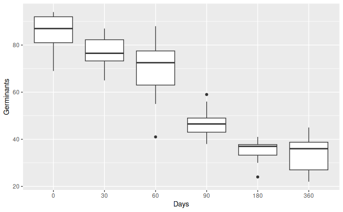

> There appears to be some effect of age on the number of germinants; it appears as if the number of germinants trends downward as the seeds get older.

## 0.3 3 Assess whether the linear model assumptions are satisfied by the data.

Treat **Days** as a factor. Use diagnostic plots.

> **Note** Here again, refer to Lab 3 for appropriate diagnostic plots. Again, the same code should work as long as you are careful to change all variable names

```
Linear mixed model fit by REML ['lmerModLmerTest']
Formula: Germinants ~ Days + (1 | Bag)
   Data: germinant_data
REML criterion at convergence: 379.1927
Random effects:
 Groups   Name        Std.Dev.
 Bag      (Intercept) 7.391
 Residual             4.855
Number of obs: 60, groups:  Bag, 30
Fixed Effects:
(Intercept)       Days30       Days60       Days90      Days180      Days360
       85.5         -8.2        -16.2        -38.3        -50.5        -52.0
```

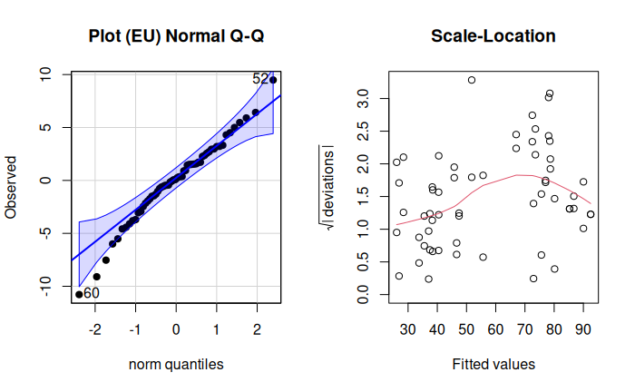

> Our normality assumption seems to be fine but our variances are all over the place. The trend line doesn’t completely go off the rails, but the hump in the middle means some of ours are a little higher than others. It’s still probably fine to go forward, but it’s cause for concern.

## 0.4 4 Test (provide p-values as evidence) if any of the extended germination times changed germination rated relative to zero days

> **Note** Refer to Lab3 for correct usage of `emmeans()` with `lmer()` models.

```
 contrast        estimate   SE df t.ratio p.value
 Days30 - Days0      -8.2 5.15 24  -1.591  0.3887
 Days60 - Days0     -16.2 5.15 24  -3.143  0.0190
 Days90 - Days0     -38.3 5.15 24  -7.431  <.0001
 Days180 - Days0    -50.5 5.15 24  -9.798  <.0001
 Days360 - Days0    -52.0 5.15 24 -10.089  <.0001

Degrees-of-freedom method: kenward-roger
P value adjustment: dunnettx method for 5 tests
```

> It appears as if for any amount of days over 30, there’s a significant difference in germination rates with a = 0.05

## 0.5 5 Repeat the analysis above, except describing which pairs of “lengths of time” caused significantly different germination rates (use α=0.05).

> Note: In an actual analysis, you would either do the analysis in #4 or #5, but not both.

Produce a table with groups of treatment levels that cannot be significantly distinguished with this α.

```
 Days emmean   SE df lower.CL upper.CL .group
 360    33.5 3.64 24     26.0     41.0  a
 180    35.0 3.64 24     27.5     42.5  a
 90     47.2 3.64 24     39.7     54.7  a
 60     69.3 3.64 24     61.8     76.8   b
 30     77.3 3.64 24     69.8     84.8   bc
 0      85.5 3.64 24     78.0     93.0    c

Degrees-of-freedom method: kenward-roger
Confidence level used: 0.95
P value adjustment: tukey method for comparing a family of 6 estimates
significance level used: alpha = 0.05
NOTE: If two or more means share the same grouping symbol,
      then we cannot show them to be different.
      But we also did not show them to be the same.
```

> There’s three groups, a, b, and c. b and c have overlap at 30 days, which makes the comparison between them a little muddy, but a is significantly different from both b and c.

For estimates reported in both analyses: Are the estimates the same? Are the lengths of the confidence interval the same? Provide an explanation for why the confidence intervals from one analyses were longer even though the data and model were the same for both analyses.

## 0.7 7 Use an ANOVA to assess the evidence for any effect of time germination rate

Is there strong evidence for a difference in germination rate by seed age?

> **Note**. The ANOVA table produced by the `lmer()` function looks a bit different from that of the `lm()` function. But all the same information is there, and it should be clear how to interpret. `DenDF` is the degrees of freedom of the denominator of the F-value. `NumDF` is the degrees of freedom of the numerator of the F-value. These are used with the `F-value` to calculate the p-value (`Pr(>F)`) using the `pf()` function.

> You should add the argument `ddf = 'Kenward-Roger'` (or abbreviation `ddf='K'` whenever you do `anova()` with a `lmer()` model

Note: The `Sum Sq` and `Mean Sq` values will be different from R’s table

Hint: Start with the `F-value` from above. You can calculate `MSE` from the `emmeans` table of Treatment effects in Question 4.

| Source | Df | Sum Sq | Mean Sq | F-value | p-value |
| --- | --- | --- | --- | --- | --- |
| Days | 5 | 15600.58 | 3120.115 | 37.678 | 1.332515e-10 |
| Residual | 24 | 1987.44 | 82.81 |  |  |